# Inference of Company X and its SKU's

#### Step 5: Evaluate

```python
# get rmse
rmse = np.sqrt(np.mean((ts_general[1:] - autoarima_model.predict_in_sample()[1:])**2))
mape = np.mean(np.abs((ts_general[1:] - autoarima_model.predict_in_sample()[1:]) / ts_general)) * 100

# print the results
print(f'RMSE: {rmse:.2f}')
print(f'MAPE: {mape:.2f}%')
```

```
RMSE: 27.51
MAPE: 4.45%
```

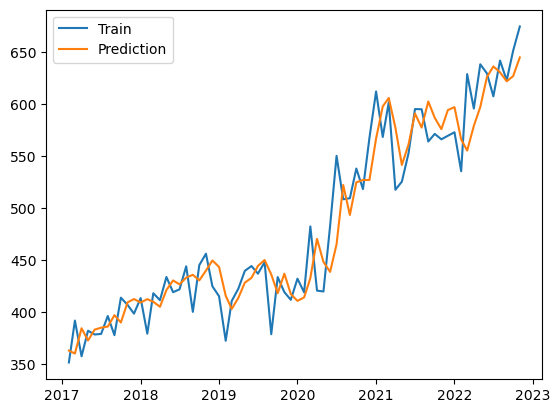

```python
# plot train vs prediction in sample
plt.plot(ts_general[1:], label='Train')
plt.plot(autoarima_model.predict_in_sample()[1:], label='Prediction')
plt.legend()
plt.show()
```

### Step 6: Forecast the next year

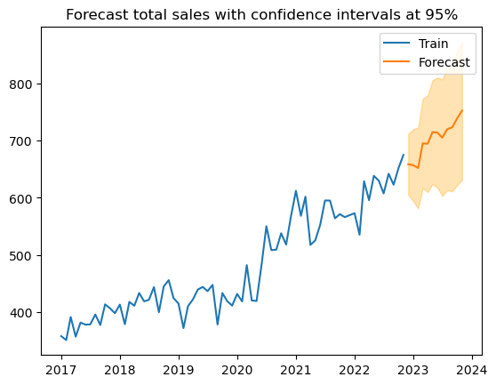

```python
# forecast the next 12 months with confidence intervals at 95%
forecast, forecast_ci = autoarima_model.predict(n_periods=12, return_conf_int=True, alpha=0.05)

# create the index for the forecast start at ts_general.index.max() + 1 month
forecast_index = pd.date_range(
    start=ts_general.index.max() + pd.DateOffset(months=1),
    periods=12,
    freq='MS'
    )

# plot
plt.plot(ts_general, label='Train')
plt.plot(forecast, label='Forecast')
plt.fill_between(forecast_index, forecast_ci[:, 0], forecast_ci[:, 1], color='orange', alpha=0.3)
plt.legend()
plt.title('Forecast total sales with confidence intervals at 95%')
plt.show()
```

*Take Aways*

- The model is a IMA(1, 1)12 which means that $y_t$ depends on the last error and the last seasonal error.
  - Which can be thought as a simple ARI($\infty$, $\infty$)12 model, which means that $y_t$ depends exponential inverse on the last $y_t$ and the last seasonal $y_t$.
  - In this case it depends $(-0.39)^{n}$ at lag $n$ and $(0.44)^{12n}$ at lag $12n$.
  - Which means that last year sales is positively correlated with the next year sales, but the last month sales is negatively correlated with the next month sales.
- There is a seaonal pattern of 12 months.
  - In combination with the EDA, we see higher sales in the second semester but decreasing on December.

## Particular TS

By time we will suppose (and the EDA and last model supports this) that the time series is an additive model. So we can use prophet to forecast the next year.

```python
from prophet import Prophet
from tqdm import tqdm

def prophet_forecast(data, periods=12):
    forecast_df = pd.DataFrame()

    for group in tqdm(data.index):
        # Prepare data for Prophet
        df = pd.DataFrame({'ds': data.columns, 'y': data.loc[group].values})

        # Fit Prophet model
        model = Prophet()
        model.fit(df)

        # Make future dataframe for forecasting
        future = model.make_future_dataframe(periods=periods, freq='M')

        # Forecast
        forecast = model.predict(future)

        # Store forecasted values in the result DataFrame
        forecast_df[group] = forecast['yhat'].tail(periods).values

    # to datetime from 2022-12 to 2023-11
    forecast_df.index = pd.date_range(start='2022-12', periods=periods, freq='M')
    # only get year and month
    forecast_df.index = forecast_df.index.strftime('%Y-%m')

    # flip
    forecast_df = forecast_df.T
    # add index name
    forecast_df.index.name = 'ZONA'

    return forecast_df

# Perform the forecast
df_forecast = prophet_forecast(df_sales)

# Display the forecasted values
df_forecast
```

[output not shown]

| ZONA | 2022-12 | 2023-01 | 2023-02 | 2023-03 | 2023-04 | 2023-05 | 2023-06 | 2023-07 | 2023-08 | 2023-09 | 2023-10 | 2023-11 |
| --- | --- | --- | --- | --- | --- | --- | --- | --- | --- | --- | --- | --- |
| 1 | 16.568250 | 20.266458 | 17.218066 | 20.536294 | 18.476485 | 21.935175 | 17.920437 | 17.933160 | 20.576661 | 21.629284 | 17.152408 | 25.326873 |
| 2 | 8.545620 | 9.687961 | 10.792849 | 8.981635 | 9.304818 | 9.536593 | 9.209002 | 9.062035 | 10.970957 | 8.724858 | 10.380148 | 11.039549 |
| 3 | 11.340718 | 11.263783 | 10.783218 | 11.257672 | 14.896822 | 12.727237 | 9.500294 | 10.311450 | 12.137314 | 13.145786 | 14.875292 | 12.365373 |
| 4 | 7.547229 | 11.202488 | 11.466816 | 9.231996 | 13.013524 | 15.511044 | 8.343432 | 6.278278 | 16.361021 | 9.968838 | 13.022732 | 12.624796 |
| 5 | 6.565238 | 7.286627 | 6.791837 | 7.830350 | 10.203211 | 10.141832 | 6.847190 | 3.807804 | 9.452881 | 8.653643 | 10.970761 | 7.917564 |
| 6 | 12.707245 | 9.262424 | 9.647439 | 15.997287 | 18.446314 | 17.120961 | 13.027792 | 5.276909 | 16.775053 | 18.083121 | 18.661559 | 14.859774 |
| 7 | 10.302010 | 9.564134 | 8.334545 | 8.643973 | 9.478481 | 7.334919 | 7.137896 | 12.908354 | 9.432988 | 9.837290 | 7.745771 | 9.542522 |
| 8 | 12.670526 | 13.398501 | 11.528969 | 12.792147 | 11.683256 | 12.677594 | 11.670296 | 11.837891 | 17.378067 | 10.664141 | 13.606349 | 13.778458 |
| 9 | 22.878464 | 22.400642 | 25.762204 | 25.611545 | 25.763876 | 27.856569 | 27.719898 | 26.757305 | 28.739102 | 30.442020 | 29.128494 | 30.702964 |
| 10 | 12.374396 | 14.471624 | 12.890336 | 13.625861 | 14.252053 | 16.259424 | 15.743345 | 14.878044 | 15.564074 | 12.477361 | 15.124928 | 18.563786 |
| 11 | 29.444700 | 18.265305 | 13.068838 | 20.454016 | 14.408444 | 27.349974 | 36.972321 | 21.585014 | 13.368549 | 9.610170 | 36.662174 | 28.222061 |
| 12 | 14.278134 | 13.780957 | 13.592831 | 13.362571 | 15.093663 | 17.959146 | 15.293164 | 12.035186 | 16.223810 | 15.716092 | 16.902721 | 15.591905 |
| 13 | 12.211918 | 11.714184 | 11.566331 | 17.511189 | 11.913581 | 14.378018 | 14.539146 | 16.839103 | 10.670823 | 12.434599 | 15.526995 | 19.744032 |
| 14 | 42.283426 | 33.513746 | 33.109246 | 51.072698 | 53.786358 | 44.484309 | 40.169844 | 40.305747 | 46.748072 | 44.634138 | 47.303135 | 64.049238 |
| 15 | 11.363859 | 12.326206 | 10.636044 | 13.360808 | 13.836416 | 14.250152 | 12.332680 | 11.903280 | 15.164695 | 13.072366 | 15.042637 | 15.163588 |
| 16 | 8.938423 | 8.647309 | 7.904665 | 9.285804 | 9.308685 | 10.856895 | 9.717331 | 7.731489 | 9.125509 | 9.373894 | 9.511379 | 11.033516 |
| 17 | 13.445256 | 12.868321 | 12.350184 | 14.175244 | 13.064472 | 18.082844 | 11.430306 | 12.899560 | 15.800169 | 13.171811 | 13.551790 | 17.306819 |
| 18 | 10.835423 | 8.921238 | 9.539309 | 11.347073 | 12.432479 | 10.618326 | 12.200307 | 9.091299 | 10.195560 | 11.284566 | 11.566457 | 12.099504 |
| 19 | 15.942091 | 9.064495 | 8.811890 | 16.666998 | 17.730621 | 15.838712 | 12.777838 | 7.062110 | 14.037833 | 13.747502 | 14.761286 | 16.927800 |
| 20 | 13.479014 | 12.053802 | 10.474233 | 11.514712 | 16.997877 | 13.798908 | 11.850899 | 12.284961 | 13.151300 | 11.087469 | 14.947568 | 13.556409 |
| 21 | 9.142203 | 8.300816 | 8.482916 | 12.892977 | 11.324825 | 12.926785 | 8.112783 | 8.465738 | 11.046251 | 9.841278 | 12.498925 | 13.905787 |
| 22 | 7.728983 | 7.090075 | 6.517683 | 8.010921 | 9.386822 | 7.374981 | 7.236339 | 6.634128 | 7.715847 | 6.302659 | 7.271067 | 8.522236 |
| 23 | 10.074556 | 9.890014 | 7.692398 | 13.020898 | 10.042472 | 15.886611 | 9.980594 | 6.124151 | 11.992666 | 10.250389 | 14.062620 | 13.063203 |
| 24 | 31.677324 | 41.036564 | 44.806243 | 44.822245 | 39.783568 | 43.452232 | 53.254515 | 28.958256 | 54.087923 | 38.902411 | 47.586349 | 56.130891 |
| 25 | 16.824721 | 14.853463 | 13.302511 | 18.375401 | 17.721802 | 20.866076 | 16.947611 | 11.013449 | 21.639355 | 14.289373 | 19.905247 | 20.235330 |
| 26 | 27.091400 | 25.491250 | 25.131549 | 30.625318 | 32.134658 | 34.998411 | 28.636505 | 23.512818 | 32.973289 | 27.590751 | 32.988379 | 35.486670 |
| 27 | 19.254434 | 17.429704 | 18.388389 | 7.597449 | 16.577031 | 22.130818 | 16.850819 | 14.653721 | 14.407340 | 17.540130 | 14.773379 | 14.714763 |
| 28 | 43.006423 | 50.535049 | 46.673549 | 35.844067 | 64.461901 | 69.424048 | 37.069843 | 44.908941 | 52.488868 | 42.084599 | 62.174121 | 64.772674 |
| 29 | 12.406063 | 11.944021 | 12.472922 | 11.140553 | 13.940655 | 14.792711 | 13.510379 | 11.952190 | 14.804310 | 11.314355 | 15.778523 | 16.124022 |
| 30 | 34.992692 | 25.733335 | 19.938761 | 33.485566 | 28.048168 | 32.041774 | 29.571753 | 26.706372 | 43.626656 | 21.914841 | 27.772664 | 35.269281 |
| 31 | 20.837508 | 23.189307 | 19.745450 | 17.600152 | 24.712157 | 21.527458 | 28.151210 | 23.065552 | 21.893394 | 15.693034 | 24.987976 | 28.414407 |
| 32 | 16.674027 | 16.028267 | 10.941408 | 16.972543 | 20.297529 | 14.446194 | 13.026660 | 17.046067 | 14.008014 | 15.595568 | 18.531894 | 18.633508 |
| 33 | 17.319278 | 21.678887 | 17.007407 | 15.459993 | 23.149606 | 19.636185 | 16.387016 | 19.120112 | 19.189154 | 17.062808 | 21.102902 | 21.957291 |
| 34 | 8.333670 | 9.105126 | 9.130079 | 7.933850 | 11.203881 | 11.839382 | 10.559586 | 8.442955 | 7.869614 | 8.930031 | 12.468378 | 12.262534 |
| 35 | 8.674896 | 10.862173 | 9.950009 | 10.316337 | 14.364884 | 12.301061 | 11.952463 | 7.775243 | 12.962789 | 9.332059 | 14.504169 | 12.530187 |
| 36 | 23.516005 | 18.787809 | 20.098837 | 27.216200 | 26.426485 | 25.149720 | 23.581066 | 19.645077 | 25.773539 | 26.649123 | 26.658432 | 26.766384 |
| 37 | 10.064118 | 9.023557 | 8.741099 | 10.055013 | 10.576138 | 14.234325 | 9.948492 | 7.096093 | 10.412226 | 10.073359 | 12.705531 | 11.857593 |
| 38 | 11.167192 | 10.414416 | 10.456766 | 13.385581 | 16.875588 | 16.114068 | 13.349890 | 9.643665 | 11.683803 | 16.678257 | 15.934379 | 15.462615 |
| 39 | 8.256435 | 9.656259 | 9.886707 | 9.233647 | 12.122528 | 12.336446 | 9.269177 | 5.228648 | 11.874069 | 11.401859 | 12.248226 | 10.947275 |

```python
df_forecast
```

| ZONA | 2022-12 | 2023-01 | 2023-02 | 2023-03 | 2023-04 | 2023-05 | 2023-06 | 2023-07 | 2023-08 | 2023-09 | 2023-10 | 2023-11 |
| --- | --- | --- | --- | --- | --- | --- | --- | --- | --- | --- | --- | --- |
| 1 | 16.568250 | 20.266458 | 17.218066 | 20.536294 | 18.476485 | 21.935175 | 17.920437 | 17.933160 | 20.576661 | 21.629284 | 17.152408 | 25.326873 |
| 2 | 8.545620 | 9.687961 | 10.792849 | 8.981635 | 9.304818 | 9.536593 | 9.209002 | 9.062035 | 10.970957 | 8.724858 | 10.380148 | 11.039549 |
| 3 | 11.340718 | 11.263783 | 10.783218 | 11.257672 | 14.896822 | 12.727237 | 9.500294 | 10.311450 | 12.137314 | 13.145786 | 14.875292 | 12.365373 |
| 4 | 7.547229 | 11.202488 | 11.466816 | 9.231996 | 13.013524 | 15.511044 | 8.343432 | 6.278278 | 16.361021 | 9.968838 | 13.022732 | 12.624796 |
| 5 | 6.565238 | 7.286627 | 6.791837 | 7.830350 | 10.203211 | 10.141832 | 6.847190 | 3.807804 | 9.452881 | 8.653643 | 10.970761 | 7.917564 |
| 6 | 12.707245 | 9.262424 | 9.647439 | 15.997287 | 18.446314 | 17.120961 | 13.027792 | 5.276909 | 16.775053 | 18.083121 | 18.661559 | 14.859774 |
| 7 | 10.302010 | 9.564134 | 8.334545 | 8.643973 | 9.478481 | 7.334919 | 7.137896 | 12.908354 | 9.432988 | 9.837290 | 7.745771 | 9.542522 |
| 8 | 12.670526 | 13.398501 | 11.528969 | 12.792147 | 11.683256 | 12.677594 | 11.670296 | 11.837891 | 17.378067 | 10.664141 | 13.606349 | 13.778458 |
| 9 | 22.878464 | 22.400642 | 25.762204 | 25.611545 | 25.763876 | 27.856569 | 27.719898 | 26.757305 | 28.739102 | 30.442020 | 29.128494 | 30.702964 |
| 10 | 12.374396 | 14.471624 | 12.890336 | 13.625861 | 14.252053 | 16.259424 | 15.743345 | 14.878044 | 15.564074 | 12.477361 | 15.124928 | 18.563786 |
| 11 | 29.444700 | 18.265305 | 13.068838 | 20.454016 | 14.408444 | 27.349974 | 36.972321 | 21.585014 | 13.368549 | 9.610170 | 36.662174 | 28.222061 |
| 12 | 14.278134 | 13.780957 | 13.592831 | 13.362571 | 15.093663 | 17.959146 | 15.293164 | 12.035186 | 16.223810 | 15.716092 | 16.902721 | 15.591905 |
| 13 | 12.211918 | 11.714184 | 11.566331 | 17.511189 | 11.913581 | 14.378018 | 14.539146 | 16.839103 | 10.670823 | 12.434599 | 15.526995 | 19.744032 |
| 14 | 42.283426 | 33.513746 | 33.109246 | 51.072698 | 53.786358 | 44.484309 | 40.169844 | 40.305747 | 46.748072 | 44.634138 | 47.303135 | 64.049238 |
| 15 | 11.363859 | 12.326206 | 10.636044 | 13.360808 | 13.836416 | 14.250152 | 12.332680 | 11.903280 | 15.164695 | 13.072366 | 15.042637 | 15.163588 |
| 16 | 8.938423 | 8.647309 | 7.904665 | 9.285804 | 9.308685 | 10.856895 | 9.717331 | 7.731489 | 9.125509 | 9.373894 | 9.511379 | 11.033516 |
| 17 | 13.445256 | 12.868321 | 12.350184 | 14.175244 | 13.064472 | 18.082844 | 11.430306 | 12.899560 | 15.800169 | 13.171811 | 13.551790 | 17.306819 |
| 18 | 10.835423 | 8.921238 | 9.539309 | 11.347073 | 12.432479 | 10.618326 | 12.200307 | 9.091299 | 10.195560 | 11.284566 | 11.566457 | 12.099504 |
| 19 | 15.942091 | 9.064495 | 8.811890 | 16.666998 | 17.730621 | 15.838712 | 12.777838 | 7.062110 | 14.037833 | 13.747502 | 14.761286 | 16.927800 |
| 20 | 13.479014 | 12.053802 | 10.474233 | 11.514712 | 16.997877 | 13.798908 | 11.850899 | 12.284961 | 13.151300 | 11.087469 | 14.947568 | 13.556409 |
| 21 | 9.142203 | 8.300816 | 8.482916 | 12.892977 | 11.324825 | 12.926785 | 8.112783 | 8.465738 | 11.046251 | 9.841278 | 12.498925 | 13.905787 |
| 22 | 7.728983 | 7.090075 | 6.517683 | 8.010921 | 9.386822 | 7.374981 | 7.236339 | 6.634128 | 7.715847 | 6.302659 | 7.271067 | 8.522236 |
| 23 | 10.074556 | 9.890014 | 7.692398 | 13.020898 | 10.042472 | 15.886611 | 9.980594 | 6.124151 | 11.992666 | 10.250389 | 14.062620 | 13.063203 |
| 24 | 31.677324 | 41.036564 | 44.806243 | 44.822245 | 39.783568 | 43.452232 | 53.254515 | 28.958256 | 54.087923 | 38.902411 | 47.586349 | 56.130891 |
| 25 | 16.824721 | 14.853463 | 13.302511 | 18.375401 | 17.721802 | 20.866076 | 16.947611 | 11.013449 | 21.639355 | 14.289373 | 19.905247 | 20.235330 |
| 26 | 27.091400 | 25.491250 | 25.131549 | 30.625318 | 32.134658 | 34.998411 | 28.636505 | 23.512818 | 32.973289 | 27.590751 | 32.988379 | 35.486670 |
| 27 | 19.254434 | 17.429704 | 18.388389 | 7.597449 | 16.577031 | 22.130818 | 16.850819 | 14.653721 | 14.407340 | 17.540130 | 14.773379 | 14.714763 |
| 28 | 43.006423 | 50.535049 | 46.673549 | 35.844067 | 64.461901 | 69.424048 | 37.069843 | 44.908941 | 52.488868 | 42.084599 | 62.174121 | 64.772674 |
| 29 | 12.406063 | 11.944021 | 12.472922 | 11.140553 | 13.940655 | 14.792711 | 13.510379 | 11.952190 | 14.804310 | 11.314355 | 15.778523 | 16.124022 |
| 30 | 34.992692 | 25.733335 | 19.938761 | 33.485566 | 28.048168 | 32.041774 | 29.571753 | 26.706372 | 43.626656 | 21.914841 | 27.772664 | 35.269281 |
| 31 | 20.837508 | 23.189307 | 19.745450 | 17.600152 | 24.712157 | 21.527458 | 28.151210 | 23.065552 | 21.893394 | 15.693034 | 24.987976 | 28.414407 |
| 32 | 16.674027 | 16.028267 | 10.941408 | 16.972543 | 20.297529 | 14.446194 | 13.026660 | 17.046067 | 14.008014 | 15.595568 | 18.531894 | 18.633508 |
| 33 | 17.319278 | 21.678887 | 17.007407 | 15.459993 | 23.149606 | 19.636185 | 16.387016 | 19.120112 | 19.189154 | 17.062808 | 21.102902 | 21.957291 |
| 34 | 8.333670 | 9.105126 | 9.130079 | 7.933850 | 11.203881 | 11.839382 | 10.559586 | 8.442955 | 7.869614 | 8.930031 | 12.468378 | 12.262534 |
| 35 | 8.674896 | 10.862173 | 9.950009 | 10.316337 | 14.364884 | 12.301061 | 11.952463 | 7.775243 | 12.962789 | 9.332059 | 14.504169 | 12.530187 |
| 36 | 23.516005 | 18.787809 | 20.098837 | 27.216200 | 26.426485 | 25.149720 | 23.581066 | 19.645077 | 25.773539 | 26.649123 | 26.658432 | 26.766384 |
| 37 | 10.064118 | 9.023557 | 8.741099 | 10.055013 | 10.576138 | 14.234325 | 9.948492 | 7.096093 | 10.412226 | 10.073359 | 12.705531 | 11.857593 |
| 38 | 11.167192 | 10.414416 | 10.456766 | 13.385581 | 16.875588 | 16.114068 | 13.349890 | 9.643665 | 11.683803 | 16.678257 | 15.934379 | 15.462615 |
| 39 | 8.256435 | 9.656259 | 9.886707 | 9.233647 | 12.122528 | 12.336446 | 9.269177 | 5.228648 | 11.874069 | 11.401859 | 12.248226 | 10.947275 |

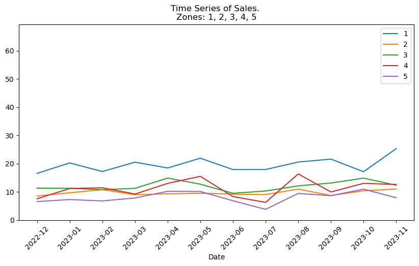

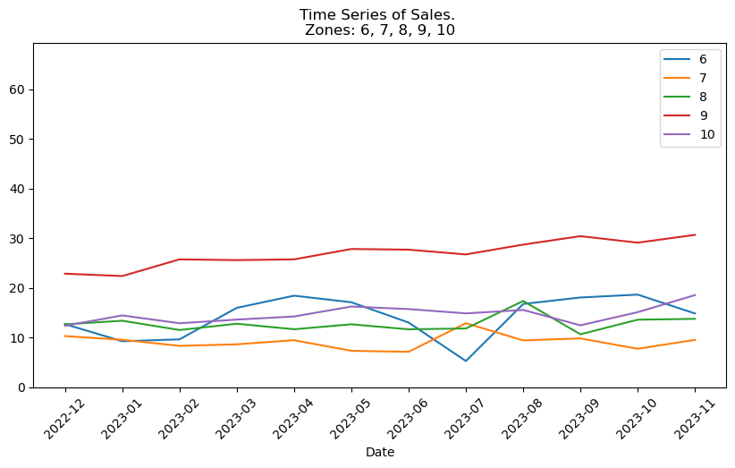

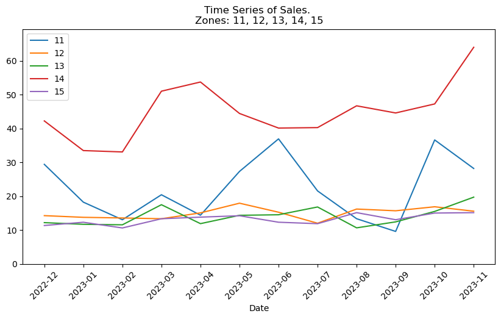

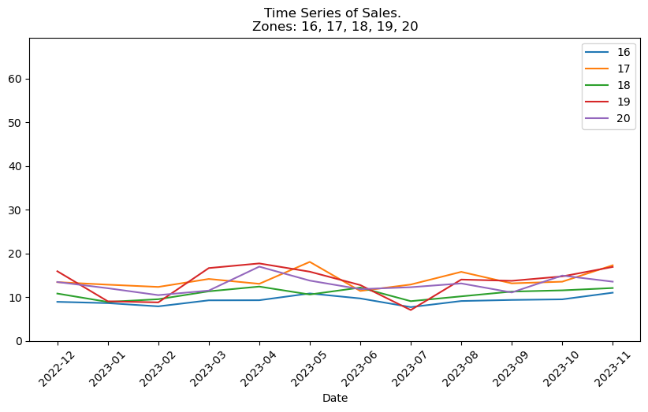

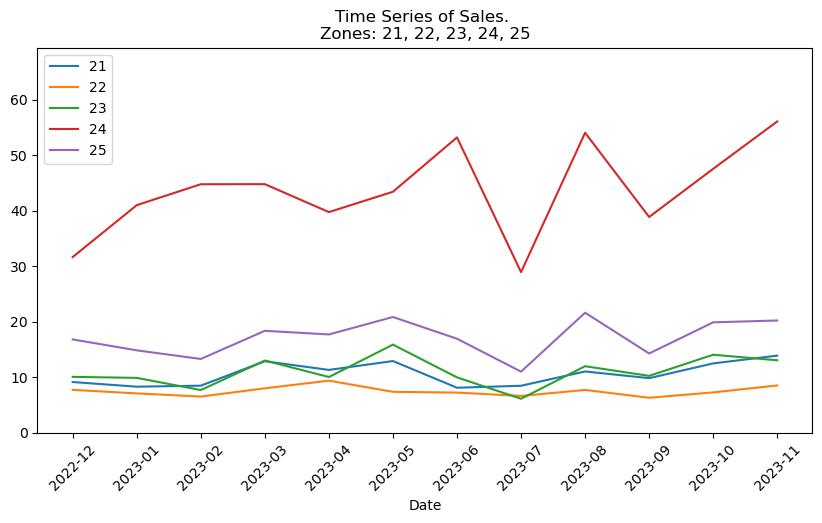

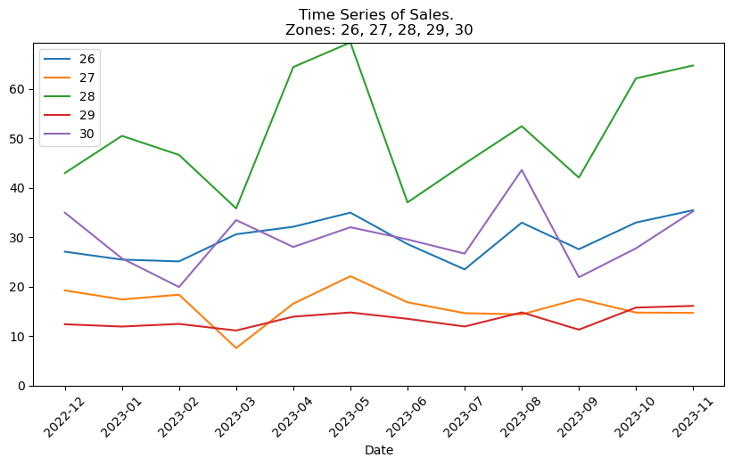

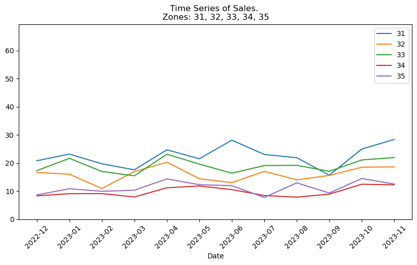

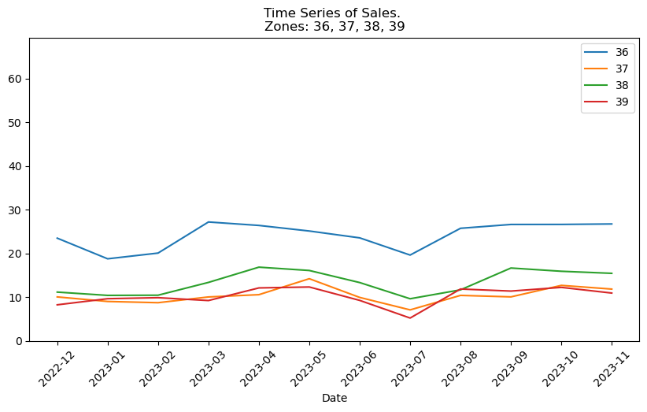

```python
# plot time series of sales
def plot_time_series(df, maxy):
    # copy
    df = df.copy()
    # plot time series using seaborn, lines should be solid
    fig, ax = plt.subplots(figsize=(10, 5))
    sns.lineplot(data=df.T, dashes=False)
    # set title
    zones = df.index.unique()
    zones = [str(zone) for zone in zones]
    ax.set_title('Time Series of Sales. \nZones: ' + ', '.join(zones))
    # show legend
    ax.legend()
    # x ticks should be dates and only show the semester
    ax.set_xticks(df.columns)
    ax.set_xticklabels(df.columns, rotation=45)
    # set x label
    ax.set_xlabel('Date')
    # set y limits
    ax.set_ylim(0, maxy)

    # show plot
    plt.show()
    return None

# 5 by 5, plot time series of sales
zones = df_forecast.index.unique()
zones = np.sort(zones)
for i in range(0, len(zones), 5):
    plot_time_series(
        df=df_forecast[df_forecast.index.isin(zones[i:i+5])],
        maxy = df_forecast.iloc[:, 1:].max().max()
        )
```

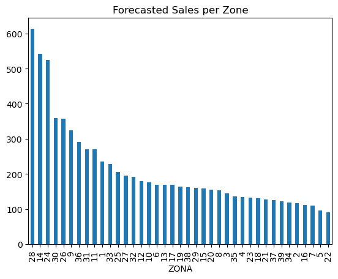

```python
# sum the forecast per zone
df_forecast_sum = df_forecast.T.sum()
df_forecast_sum = df_forecast_sum.sort_values(ascending=False)
# bar plot of the forecast in the given order
df_forecast_sum.plot(kind='bar')
plt.title('Forecasted Sales per Zone')
plt.show()
```

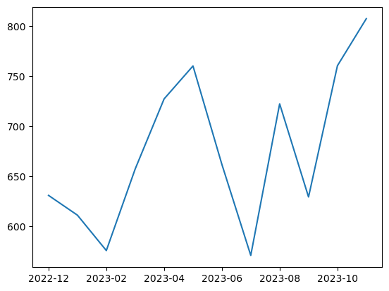

```python
# sum the forecast per month and look at the time series
df_forecast_sum_month = df_forecast.sum()
df_forecast_sum_month.plot()
```

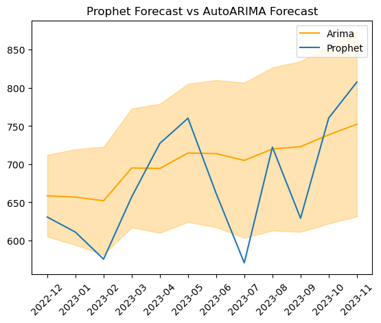

```python
# compare the df_forecast_sum_month with autoarima_model
plt.plot(forecast.index.strftime('%Y-%m'), forecast, label='Arima', color='orange')
# index to year-month
plt.fill_between(forecast_index.strftime('%Y-%m') , forecast_ci[:, 0], forecast_ci[:, 1], color='orange', alpha=0.3)
plt.plot(df_forecast_sum_month, label='Prophet')
# x axis rotation
plt.xticks(rotation=45)
# title
plt.title('Prophet Forecast vs AutoARIMA Forecast')

plt.legend()
```

# Segmentation

## Zones by sales

Segment the zones that are correlated with the sales of the company. We will use correlation and clustering to find the zones that are similar in sales.

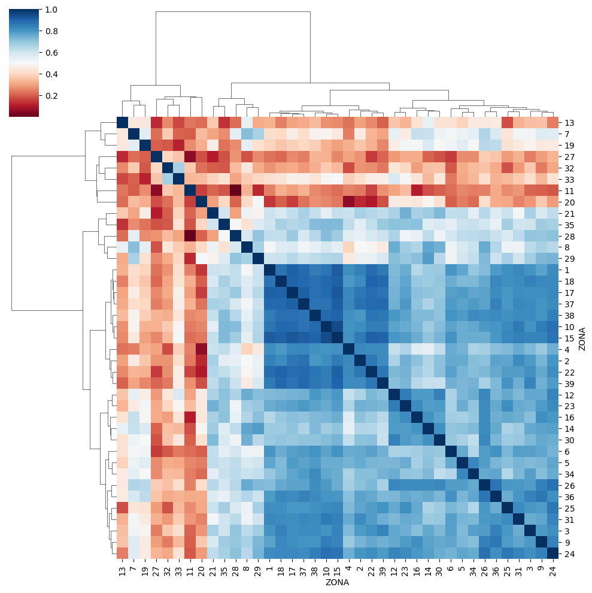

```python
# copy
df_corr = df_sales.copy()

# set ZONA as index
df_corr = df_corr.T

# get correlation matrix
X_corr = df_corr.corr(method='spearman')

# corrplot clustering by variables
sns.clustermap(X_corr, cmap='RdBu', method='ward')
```

[output not shown]

[output cut: 25 more lines]

[output not shown]

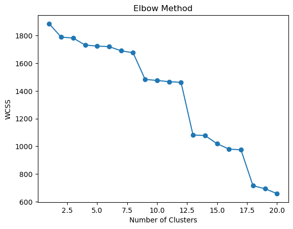

```python
# use cosine similarity to cluster the zones
from sklearn.cluster import AgglomerativeClustering
from sklearn.metrics import pairwise_distances
from scipy.spatial.distance import cosine

# Cosine similarity function using spearman correlation
def correlation_similarity(data):
    return 1 - pd.DataFrame(data).T.corr(method='spearman').values

# Hierarchical clustering with Ward linkage
def hierarchical_clustering(data, n_clusters):
    D = correlation_similarity(data)
    clustering = AgglomerativeClustering(
        n_clusters=n_clusters, linkage='average', affinity='precomputed', compute_full_tree=True,
        )
    clustering.fit(D)
    return clustering.labels_

# Function to calculate the total within-cluster sum of squares (wcss)
def calculate_wcss(data, labels):
    wcss = 0
    unique_labels = np.unique(labels)
    for label in unique_labels:
        cluster_points = data[labels == label]
        centroid = cluster_points.mean(axis=0)
        wcss += np.sum((cluster_points - centroid) ** 2)
    return wcss

# Elbow method to find optimal number of clusters
def elbow_method(data, max_clusters):
    wcss_values = []
    for i in range(1, max_clusters + 1):
        labels = hierarchical_clustering(data, i)
        wcss = calculate_wcss(data, labels).mean()
        wcss_values.append(wcss)
    return wcss_values

# Generate elbow graph
def plot_elbow_graph(wcss_values):
    plt.plot(range(1, len(wcss_values) + 1), wcss_values, marker='o')
    plt.title('Elbow Method')
    plt.xlabel('Number of Clusters')
    plt.ylabel('WCSS')
    plt.show()

# Set maximum number of clusters to test
max_clusters = 20

# Perform hierarchical clustering and calculate WCSS for each number of clusters
wcss_values = elbow_method(df_sales, max_clusters)

# Plot the elbow graph
plot_elbow_graph(wcss_values)
```

```python
# hierarchical clustering
n_clusters = 9
labels = hierarchical_clustering(df_sales, n_clusters)

# add the labels to the df_sales
df_clusters = df_sales.copy()
df_clusters['cluster'] = labels + 1
```

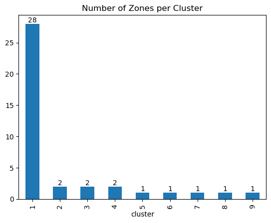

```python
# look distribution of the clusters
df_clusters['cluster'].value_counts().sort_index().plot(kind='bar')
# add value
for i, value in enumerate(df_clusters['cluster'].value_counts().sort_index()):
    plt.text(i, value, str(value), ha='center', va='bottom')
# title
plt.title('Number of Zones per Cluster')
```